# Functions and Graphs in Biological Modeling

March, 2025

## Functions in Biological Modeling

- A **function** is a mathematical relationship between two variables, typically denoted as \(f(x)\).
- \(f(x)\) takes input \(x\) and produces output \(f(x)\).
- The mathematical notion of a function is not entirely different from the programming concept of a function (but also not entirely the same).

## Mathematical Functions vs Programming Functions

- **Mathematical Functions**: A relationship between two variables, typically denoted as \(f(x)\).
- **Programming Functions**: A block of code that can be used to perform a specific task.
- **Similarities**: Both take input and produce output.
- **Differences**: Mathematical functions are subject to more constraints than programming functions. E.g., the must be one-to-one such that \(f(x)\) is unique for each for each \(x\).

## Linear Functions

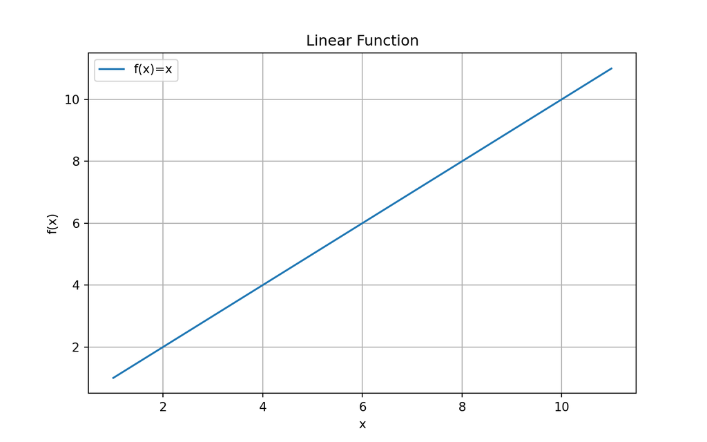

## Exponential Functions

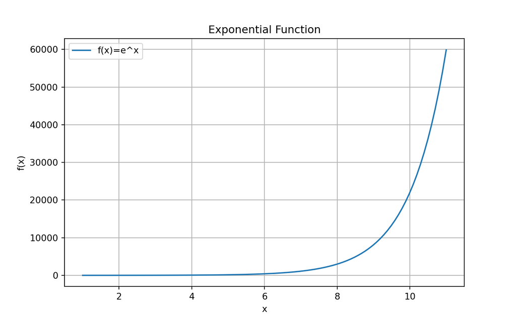

## Logarithmic Functions

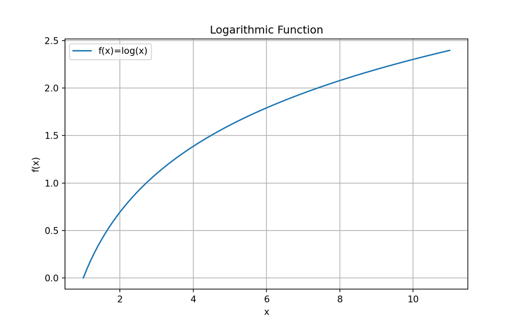

## X-Axis Translation

- \(f(x+a)\) slides the shape of the function \(f(x)\) to the left along the x-axis by \(a\) units.

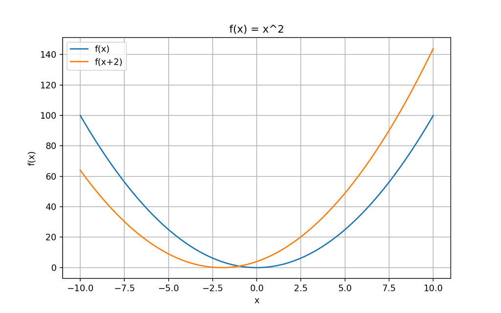

## X-Axis Translation

- \(f(x-a)\) slides the shape of the function \(f(x)\) to the right along the x-axis by \(a\) units.

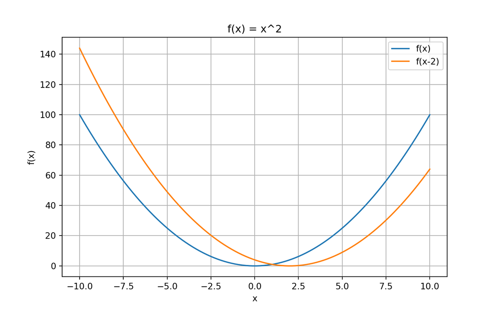

## Y-Axis Translation

- \(f(x)+a\) slides the shape of the function \(f(x)\) up along the y-axis by \(a\) units.

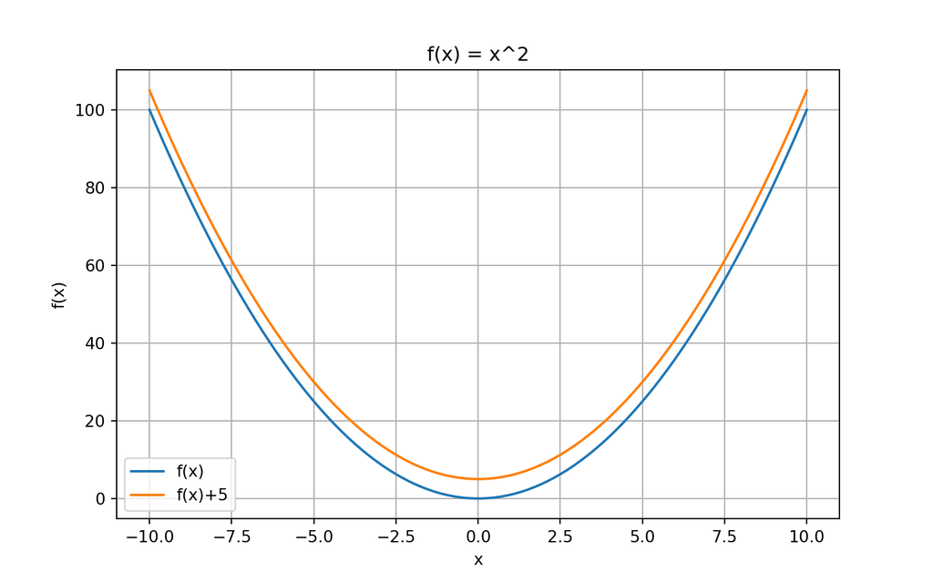

## Y-Axis Translation

- \(f(x)-a\) slides the shape of the function \(f(x)\) down along the y-axis by \(a\) units.

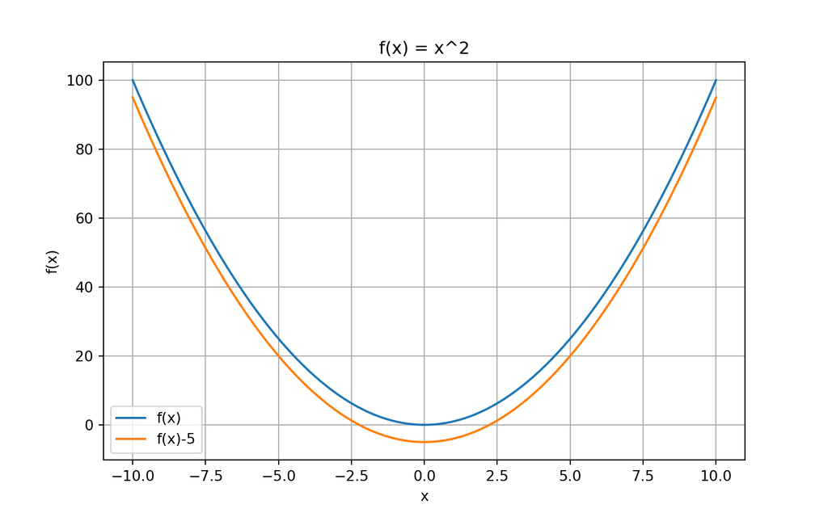

## Reflections

- \(f(-x)\) reflects the shape of the function \(f(x)\) in the y-axis.

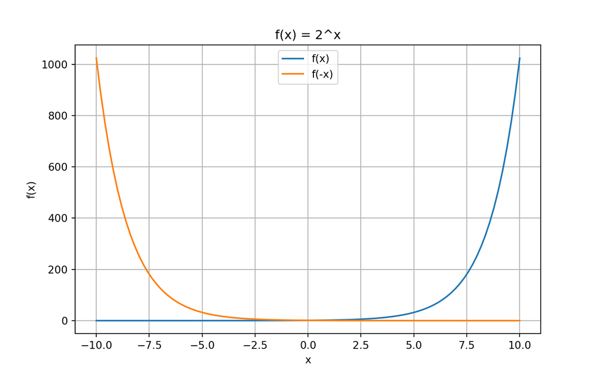

## Reflections

- \(-f(x)\) reflects the shape of the function \(f(x)\) in the x-axis.

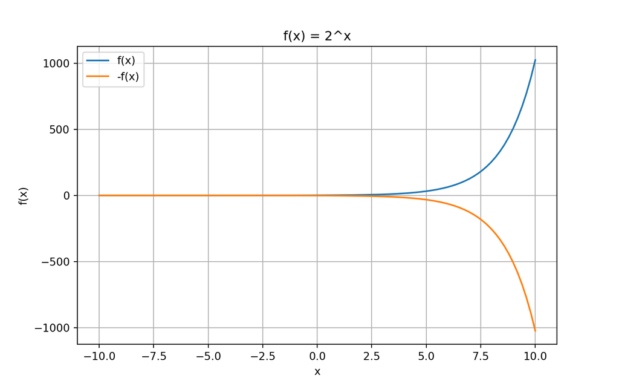

## Multiple Choice Questions

Consider the plots below and answer the following questions:

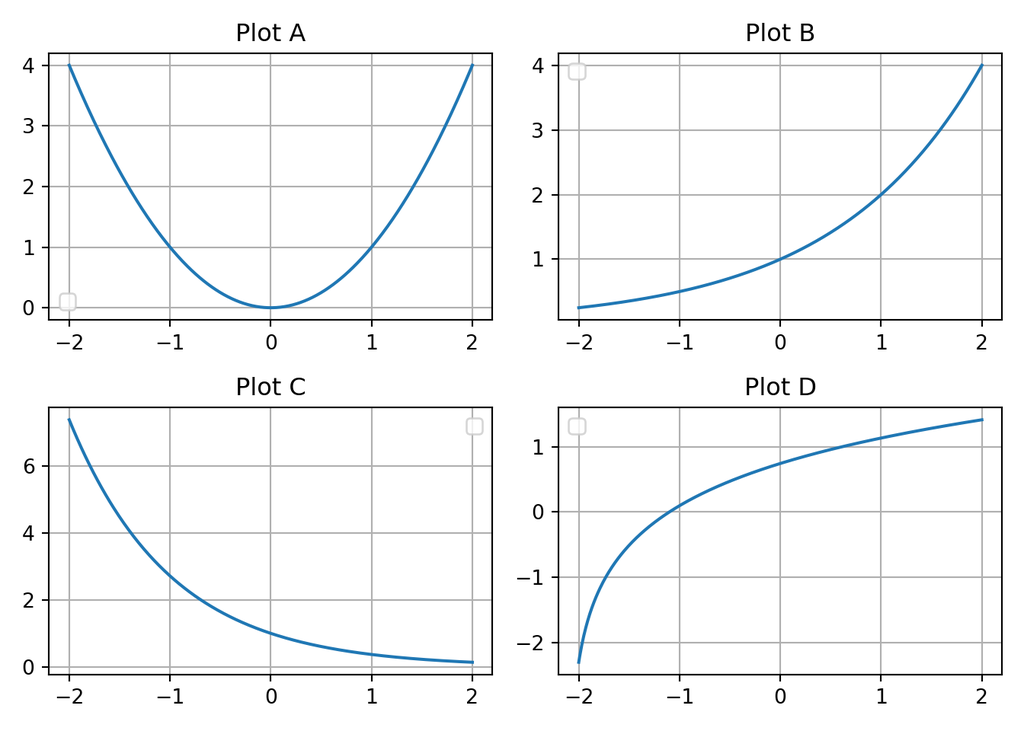

## Question 1

Which plot represents the function \(f(x) = x^2\)?

- 1. Plot A
- 1. Plot B
- 1. Plot C
- 1. Plot D

**Click to see the answer**

**Correct Answer: A) Plot A**

## Question 2

Which plot represents the function \(f(x) = 2^x\)?

- 1. Plot A
- 1. Plot B
- 1. Plot C
- 1. Plot D

**Click to see the answer**

**Correct Answer: B) Plot B**

## Question 3

Which plot represents the function \(f(x) = e^{-x}\)?

- 1. Plot A
- 1. Plot B
- 1. Plot C
- 1. Plot D

**Click to see the answer**

**Correct Answer: C) Plot C**

## Question 4

Which plot represents the function \(f(x) = \log(x+2.1)\)?

- 1. Plot A
- 1. Plot B
- 1. Plot C
- 1. Plot D

**Click to see the answer**

**Correct Answer: D) Plot D**